KNN Validation

[Full Code](https://github.com/Roctober92/senior_project_scripts/blob/master/r_knn/validate_knn.R)

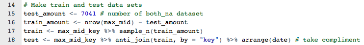

I then applied the functions that finds stations of the same date, as well as the month, and saves their values.

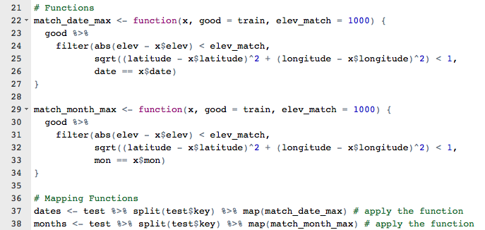

Each rows of the missing dataset returned a certain amount of nearby stations. I made histograms showing how many nearby stations per row were returned. The algorithm that looked for **same month** rather than **same date** intuitively returned more rows per station.

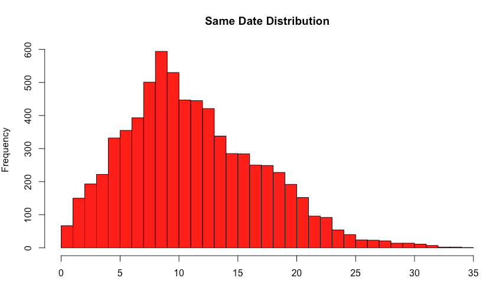

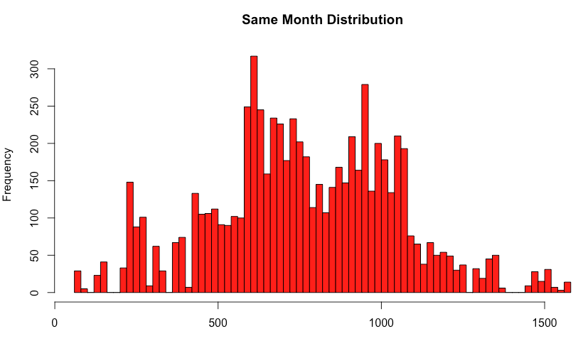

For every row of missing data, I took both the **mean** and **median** of the nearby stations’ temperature, just to see if one provided any useful information over the other.

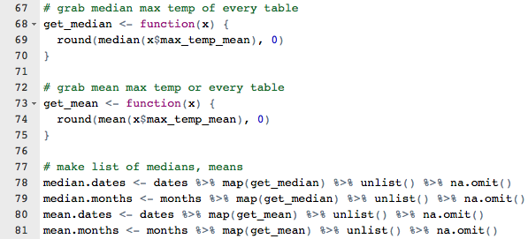

Since the validation is done using a random sample of the data every time, the calculated SSE will be different. Through running through the process times, however, the trends I find are:

- **Date** SSE is much smaller than **month** SSE, for both mean and median
- **Mean** SSE is just barely smaller than **median** SSE

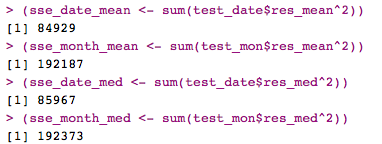

In the real KNN, I will use mean. I will also provide residual histograms of both predictions, using the mean. You can see how the **same date** stations have a much tighter hold around 0, meaning the predicitons were more accurate.

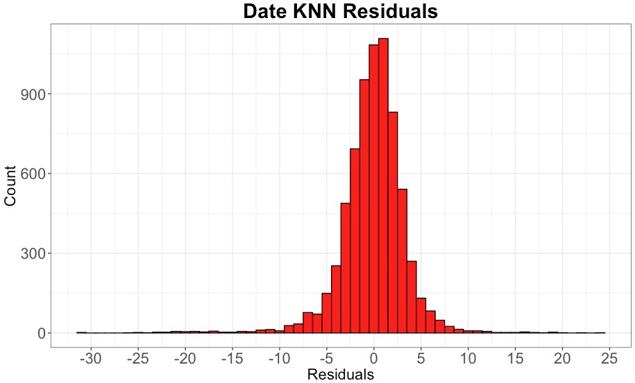

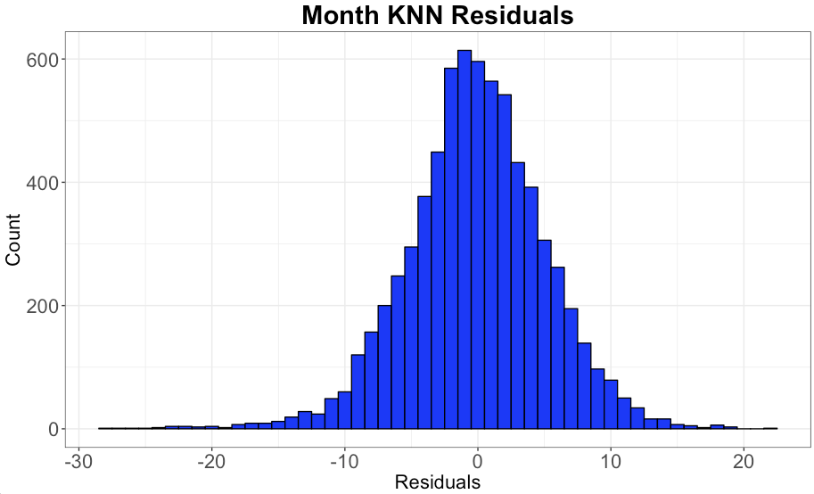